# Final Project Graphs

Brian Anderson and Daniel Beidelshcies

```r
library(tidyverse)     # for graphing and data cleaning
library(lubridate)     # for date manipulation
library(ggthemes)      # for even more plotting theme
library(gganimate)     # for adding animation layers to ggplots
library(transformr)    # for "tweening" (gganimate)
library(gifski)        # for creating the gif
library(shiny)         # for creating interactive apps
library(readr)
theme_set(theme_minimal()) # My favorite ggplot() theme :)
```

## Data choice: Video Game Sales

```r
vgsales <- read_csv("vgsales.csv", col_types = cols(Year = col_integer()))
vgsales
```

| Rank | Name | Platform | Year | Genre | Publisher | NA_Sales | EU_Sales | JP_Sales | Other_Sales | Global_Sales |
| --- | --- | --- | --- | --- | --- | --- | --- | --- | --- | --- |
| 1 | Wii Sports | Wii | 2006 | Sports | Nintendo | 41.49 | 29.02 | 3.77 | 8.46 | 82.74 |
| 2 | Super Mario Bros. | NES | 1985 | Platform | Nintendo | 29.08 | 3.58 | 6.81 | 0.77 | 40.24 |
| 3 | Mario Kart Wii | Wii | 2008 | Racing | Nintendo | 15.85 | 12.88 | 3.79 | 3.31 | 35.82 |
| 4 | Wii Sports Resort | Wii | 2009 | Sports | Nintendo | 15.75 | 11.01 | 3.28 | 2.96 | 33.00 |
| 5 | Pokemon Red/Pokemon Blue | GB | 1996 | Role-Playing | Nintendo | 11.27 | 8.89 | 10.22 | 1.00 | 31.37 |
| 6 | Tetris | GB | 1989 | Puzzle | Nintendo | 23.20 | 2.26 | 4.22 | 0.58 | 30.26 |
| 7 | New Super Mario Bros. | DS | 2006 | Platform | Nintendo | 11.38 | 9.23 | 6.50 | 2.90 | 30.01 |
| 8 | Wii Play | Wii | 2006 | Misc | Nintendo | 14.03 | 9.20 | 2.93 | 2.85 | 29.02 |
| 9 | New Super Mario Bros. Wii | Wii | 2009 | Platform | Nintendo | 14.59 | 7.06 | 4.70 | 2.26 | 28.62 |
| 10 | Duck Hunt | NES | 1984 | Shooter | Nintendo | 26.93 | 0.63 | 0.28 | 0.47 | 28.31 |

[output cut: 9990 more lines]

### Final Project Outline

#### Title:

In the YAML section of the document. A descriptive title & list of all group members.

*Exploring the World of Video Games*

Daniel Beidelschies and Brian Anderson

#### Introduction and Background:

An introduction that motivates & outlines a clear, specific set of research questions. Also, provide some background on your topic.

##### Introduction

Since the advancement of technology, the creation of video games has played an influential role in being a source of entertainment for everyone around the world. From the multitude of video games that have been created, everyone is able to find a game that they enjoy in order to pass time, have fun, and fulfill their creative needs. With this idea, we wanted to look at how well different games, genres, and platforms did when it came to releasing games for everyone to play. Based on the sales around of the world, we will be able to understand how popularity ranks up between different types of games.

##### Background information

Since our individual discovery, we have always had interest in video games and wondered how the sales of these games differed across the world as we grew up in different regions.

#### Research Questions

What are the most selling platforms of games over the years across different regions?

What is the most selling genre of games over the years across different regions?

#### Data collection:

Specification of your data sources and collection process.

Scraping from Kaggle and importing to a dataset

#### Analysis:

This is the bulk of the report which either has a presentation of the group’s key findings and take-aways or gives the detail of how someone would interact and what people should take away from the shiny app. If you choose to do a shiny app, be sure to include a link to the shinyapps.io site.

```r
vgsales %>%
  group_by( Year,Genre) %>%
  summarize(total_genre_sum = sum(Global_Sales)) %>%
  ungroup() %>%
  complete(Year,Genre) %>%
  arrange(Genre,Year) %>%
  group_by(Genre) %>%
  replace_na(list(total_genre_sum = 0)) %>%
  mutate(cum_genre_sum = cumsum(total_genre_sum)) %>%
  filter(cum_genre_sum > 0) %>%
  filter(n()>=13) %>%
  top_n(n = 12,wt = cum_genre_sum) %>%
  arrange(Year,desc(cum_genre_sum)) %>%
  mutate(rank = 1:n()) %>%
  ggplot(aes(x = cum_genre_sum,
             y = factor(rank),
             fill = Genre,
             group = Genre)) +
  geom_col() +
  geom_text(aes(label = Genre),
            color = "white",
            hjust = "right") +
  labs(title = "Popular Video Game Genres based on Worldwide Sales",
       subtitle = "Year: {frame_time}",
       x = "",
       y = "",
       caption = "Plot created by Brian Anderson, Data from Vgsales") +
  transition_time(Year)
```

```
## Error in seq.default(range[1], range[2], length.out = nframes): 'from' must be a finite number
```

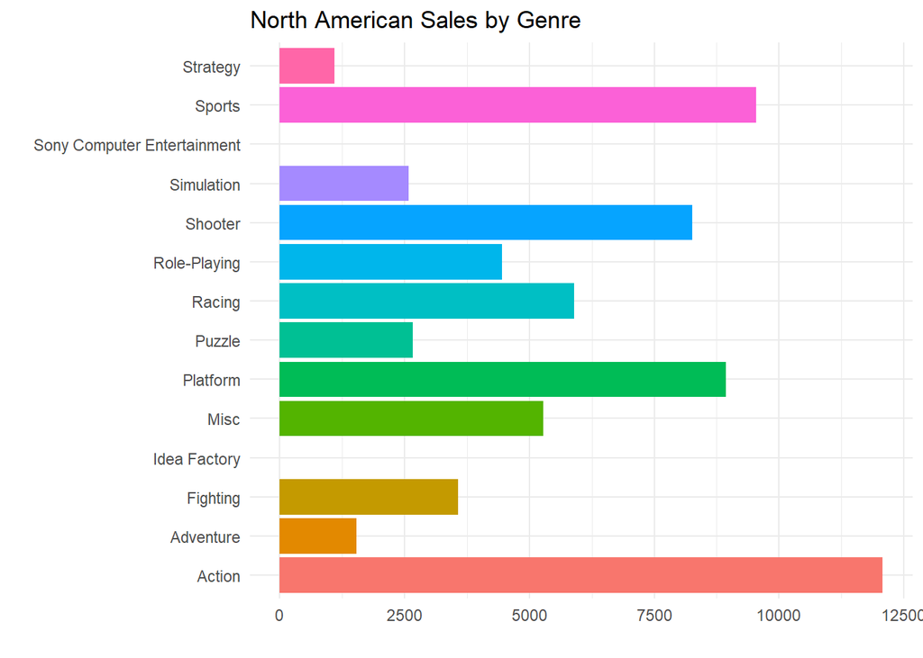

```r
regiongenresales <- vgsales %>%
  group_by( Year,Genre) %>%
  summarize(total_NA_genre_sum = sum(NA_Sales),
            total_EU_genre_sum = sum(EU_Sales),
            total_JP_genre_sum = sum(JP_Sales),
            total_other_genre_sum = sum(Other_Sales)) %>%
  ungroup() %>%
  complete(Year,Genre) %>%
  arrange(Genre,Year) %>%
  group_by(Genre) %>%
  replace_na(list(total_NA_genre_sum = 0, total_EU_genre_sum  = 0, total_JP_genre_sum  = 0, total_other_genre_sum = 0)) %>%
  mutate(cum_NA_genre_sum = cumsum(total_NA_genre_sum), cum_EU_genre_sum = cumsum(total_EU_genre_sum),cum_JP_genre_sum = cumsum(total_JP_genre_sum),cum_other_genre_sum = cumsum(total_other_genre_sum))


g1 <- ggplot(regiongenresales)+
  geom_col(aes(x = cum_NA_genre_sum,
             y = Genre,
             fill = Genre,
             group = Genre))+
  labs(x="", y= "", title ="North American Sales by Genre")+
  theme(legend.position = "none")

g2 <- ggplot(regiongenresales)+
  geom_col( aes(x = cum_EU_genre_sum,
             y = Genre,
             fill = Genre,
             group = Genre))+
  labs(x="", y= "", title ="European Sales by Genre")+
  theme(legend.position = "none")

g3 <- ggplot(regiongenresales)+
  geom_col(aes(x = cum_JP_genre_sum,
             y = Genre,
             fill = Genre,
             group = Genre))+
  labs(x="", y= "", title ="Japanese Sales by Genre")+
  theme(legend.position = "none")

g4 <- ggplot(regiongenresales)+
  geom_col(aes(x = cum_other_genre_sum,
             y = Genre,
             fill = Genre,
             group = Genre))+
  labs(x="", y= "", title ="Other Region Sales by Genre")+
  theme(legend.position = "none")


g1
```

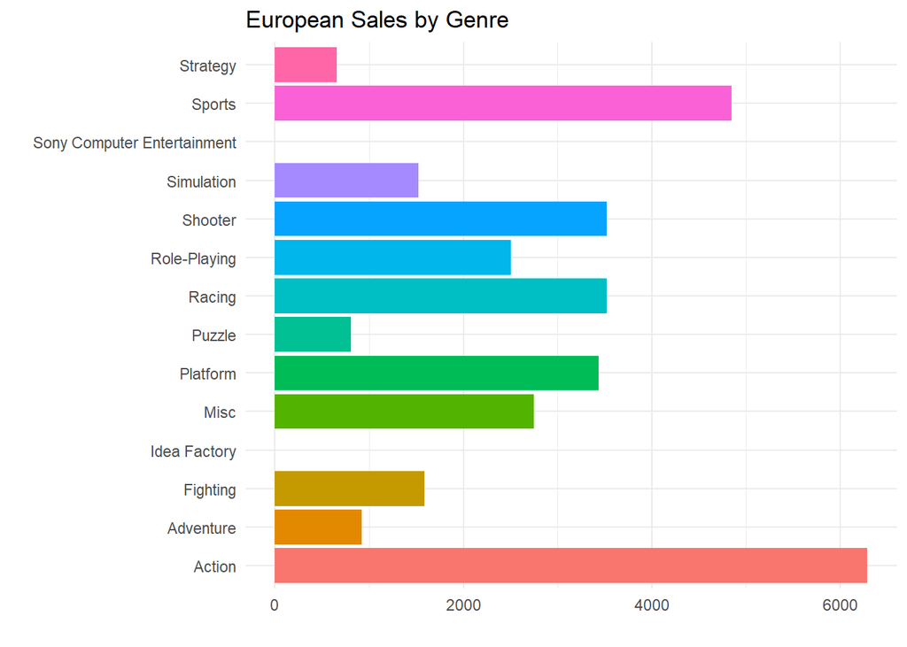

```r
g2
```

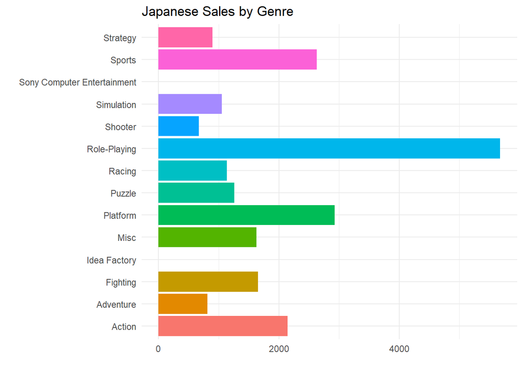

```r
g3
```

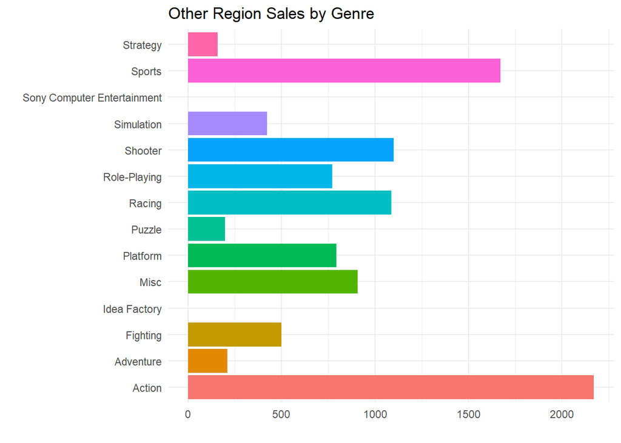

```r
g4
```

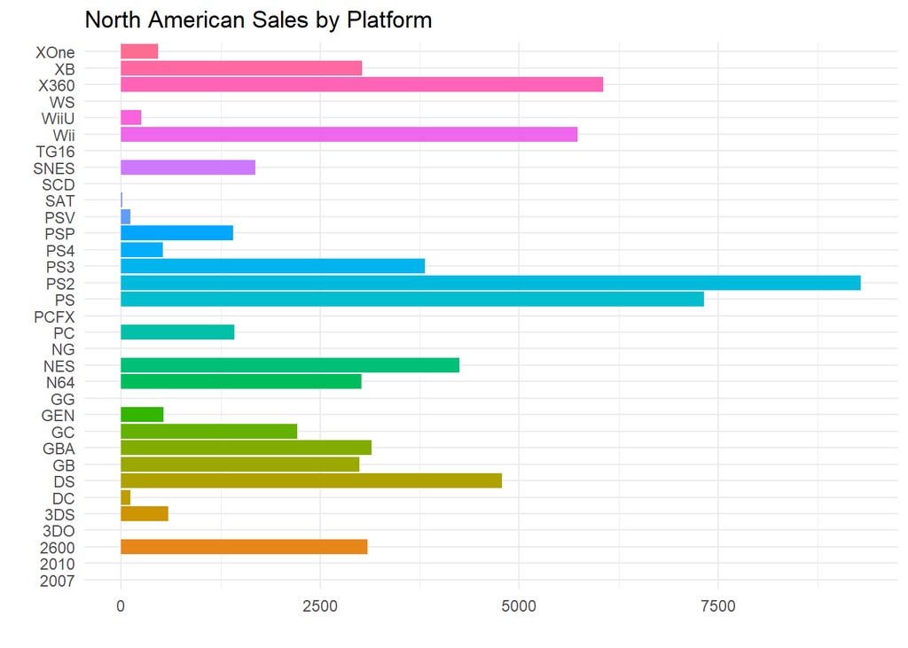

```r
regionplatformsales <- vgsales %>%
  group_by( Year,Platform) %>%
  summarize(total_NA_platform_sum = sum(NA_Sales),
            total_EU_platform_sum = sum(EU_Sales),
            total_JP_platform_sum = sum(JP_Sales),
            total_other_platform_sum = sum(Other_Sales)) %>%
  ungroup() %>%
  complete(Year,Platform) %>%
  arrange(Platform,Year) %>%
  group_by(Platform) %>%
  replace_na(list(total_NA_platform_sum = 0, total_EU_platform_sum  = 0, total_JP_platform_sum  = 0, total_other_platform_sum = 0)) %>%
  mutate(cum_NA_platform_sum = cumsum(total_NA_platform_sum), cum_EU_platform_sum = cumsum(total_EU_platform_sum),cum_JP_platform_sum = cumsum(total_JP_platform_sum),cum_other_platform_sum = cumsum(total_other_platform_sum))


p1 <- ggplot(regionplatformsales)+
  geom_col(aes(x = cum_NA_platform_sum,
             y = Platform,
             fill = Platform,
             group = Platform))+
  labs(x="", y= "", title ="North American Sales by Platform")+
  theme(legend.position = "none")

p2 <- ggplot(regionplatformsales)+
  geom_col( aes(x = cum_EU_platform_sum,
             y = Platform,
             fill = Platform,
             group = Platform))+
  labs(x="", y= "", title ="European Sales by Platform")+
  theme(legend.position = "none")

p3 <- ggplot(regionplatformsales)+
  geom_col(aes(x = cum_JP_platform_sum,
             y = Platform,
             fill = Platform,
             group = Platform))+
  labs(x="", y= "", title ="Japanese Sales by Platform")+
  theme(legend.position = "none")

p4 <- ggplot(regionplatformsales )+
  geom_col(aes(x = cum_other_platform_sum,
             y = Platform,
             fill = Platform,
             group = Platform))+
  labs(x="", y= "", title ="Other Region Sales by Platform")+
  theme(legend.position = "none")


p1
```

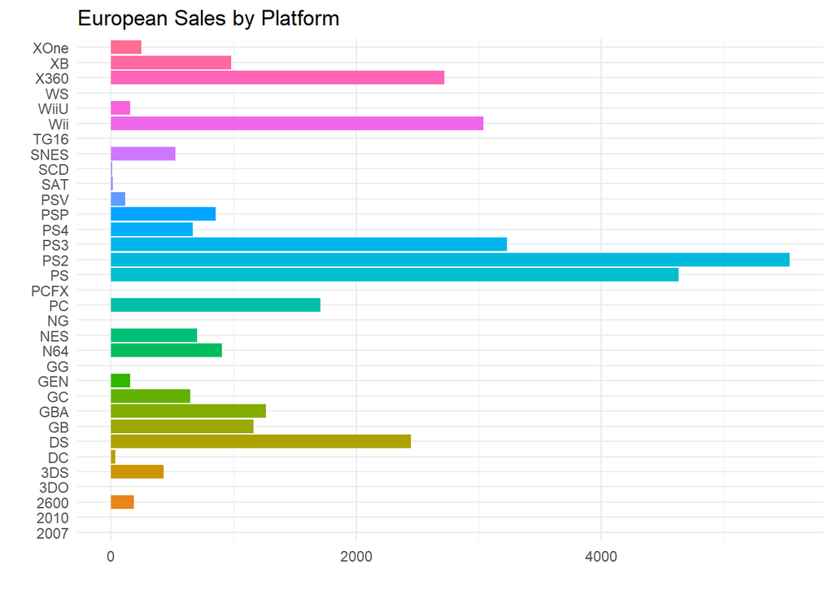

```r
p2
```

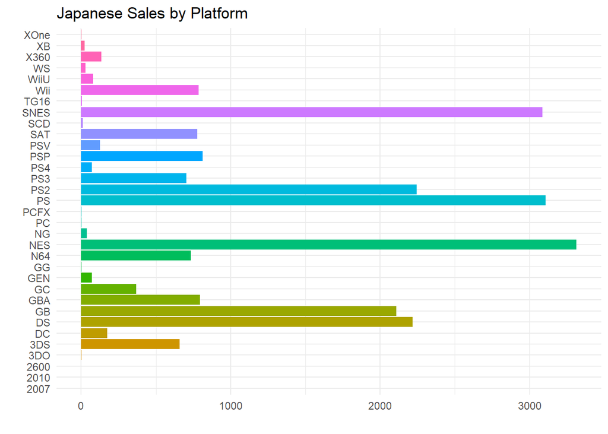

```r
p3
```

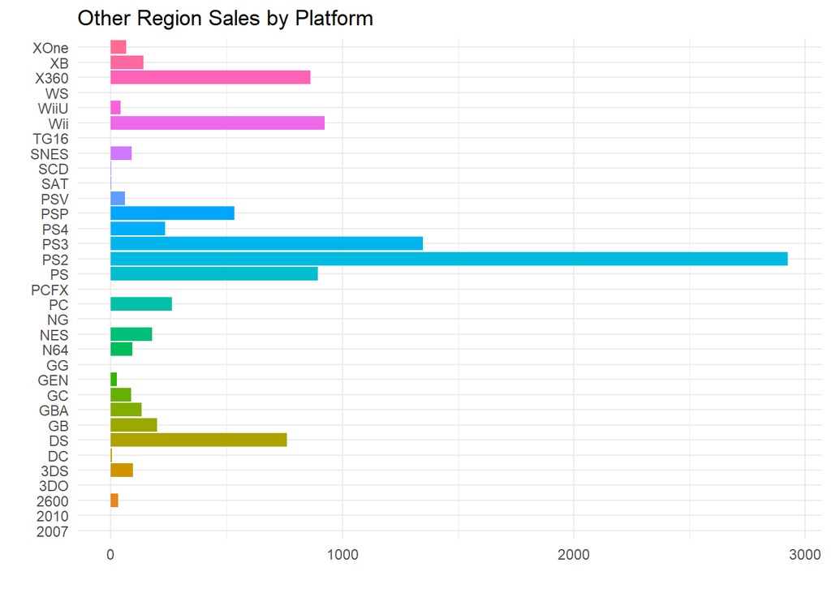

```r
p4
```